# BF_Final_Exam

###### ACF plot of the residuals

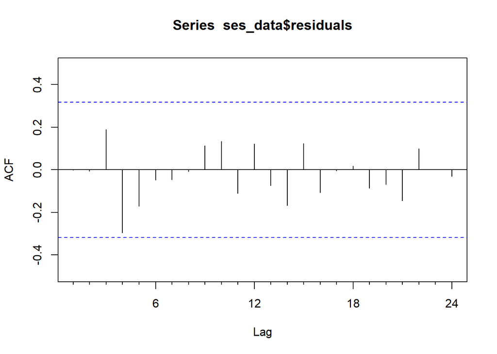

```r
Acf(ses_data$residuals)
```

- Most residual lags fall within the confidence bounds, indicating randomness.
- Slight autocorrelation at lower lags suggests minor patterns in residuals.
- The overall randomness confirms the model effectively explains the data.
- Residual ACF supports the validity of the Simple Exponential Smoothing model for this dataset.

##### Accuracy

```r
accuracy(ses_data)
```

```
##                       ME      RMSE       MAE        MPE     MAPE      MASE
## Training set -0.01515562 0.8469966 0.6412639 -0.2569269 4.204252 0.3493601
##                      ACF1
## Training set -0.001220629
```

##### Forecast

```r
ses_data
```

```
##          Point Forecast    Lo 80    Hi 80    Lo 95    Hi 95
## Mar 2024       16.13933 15.02412 17.25455 14.43376 17.84491
## Apr 2024       16.13933 14.62782 17.65085 13.82767 18.45100
## May 2024       16.13933 14.31570 17.96297 13.35032 18.92835
## Jun 2024       16.13933 14.04968 18.22898 12.94349 19.33518
## Jul 2024       16.13933 13.81391 18.46476 12.58290 19.69577
## Aug 2024       16.13933 13.59993 18.67874 12.25565 20.02302
## Sep 2024       16.13933 13.40263 18.87604 11.95390 20.32477
## Oct 2024       16.13933 13.21862 19.06004 11.67249 20.60617
## Nov 2024       16.13933 13.04555 19.23312 11.40779 20.87087
## Dec 2024       16.13933 12.88165 19.39702 11.15714 21.12153
```

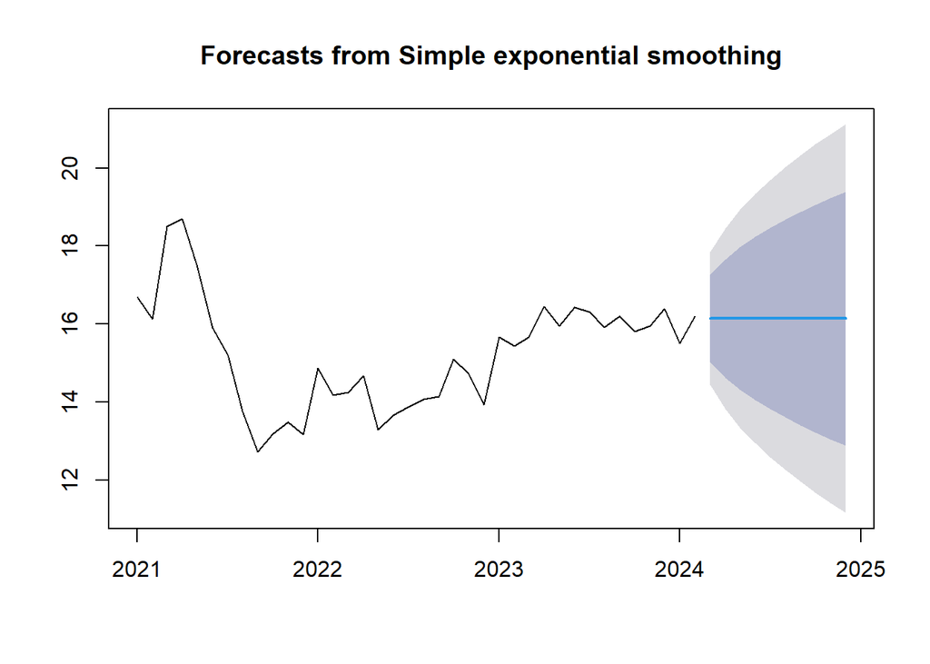

```r
plot(ses_data)
```

- The forecast stabilizes around a constant value, reflecting the smoothing model.
- Widen over time, indicating increased uncertainty in longer-term forecasts.
- The method captures no significant trend changes, providing a flat projection.
- Simple exponential smoothing is appropriate for stable data without strong seasonality or trends.

##### Simple Smoothing Summary

- MAPE: 4.20%, indicating small percentage errors and good accuracy.
- Residual Behavior: Random residuals with minimal autocorrelation (ACF1 = -0.0012).
- Overall Fit: Performs well for stationary data without trends or seasonality.
- Predicted value stabilizes at 16.13933 for the next year.
- Forecast intervals widen symmetrically as uncertainty increases.
- Stability: Works well for stationary time series data.
- Uncertainty: Wider prediction intervals reflect growing uncertainty over time.
- Limitation: Does not handle seasonality or trends, making it unsuitable for non-stationary data.

## Holt-Winters

- The Holt-Winters Method, also known as Triple Exponential Smoothing, is a powerful forecasting technique for time-series data that incorporates trend and seasonality components in addition to the level of the data. It extends the simpler exponential smoothing methods by accounting for data patterns that change over time.

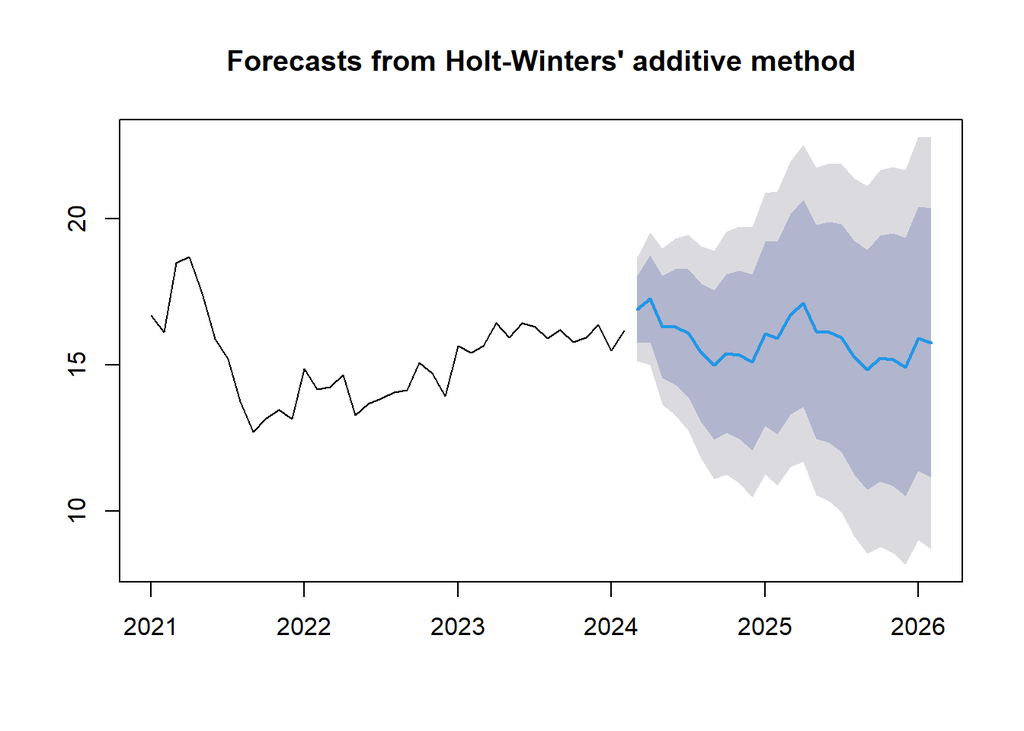

```r
Hw_forecast <- hw(sales_ts_window, seasonal = "additive")
plot(forecast(Hw_forecast))
```

```r
attributes(Hw_forecast)
```

```
## $names
##  [1] "model"     "mean"      "level"     "x"         "upper"     "lower"
##  [7] "fitted"    "method"    "series"    "residuals"
##
## $class
## [1] "forecast"
```

```r
Hw_add <- forecast(Hw_forecast)
```

- Holt-Winters’ additive method accounts for both trend and seasonality.
- The forecast captures periodic fluctuations, aligning with the observed seasonal pattern.
- The forecast shows a stable trend with slight seasonal variations
- Widen over time, reflecting increasing uncertainty with a longer forecast horizon.
- Appropriate for time series with additive seasonality and consistent trends.

###### Observations

```r
Hw_add$model
```

```
## Holt-Winters' additive method
##
## Call:
## hw(y = sales_ts_window, seasonal = "additive")
##
##   Smoothing parameters:
##     alpha = 0.807
##     beta  = 1e-04
##     gamma = 1e-04
##
##   Initial states:
##     l = 16.1108
##     b = -0.0142
##     s = -0.7835 -0.5428 -0.5113 -0.9156 -0.5135 0.152
##            0.3342 0.3312 1.28 0.8947 0.0681 0.2065
##
##   sigma:  0.8982
##
##      AIC     AICc      BIC
## 143.2981 173.8981 171.1371
```

##### Residual Analysis

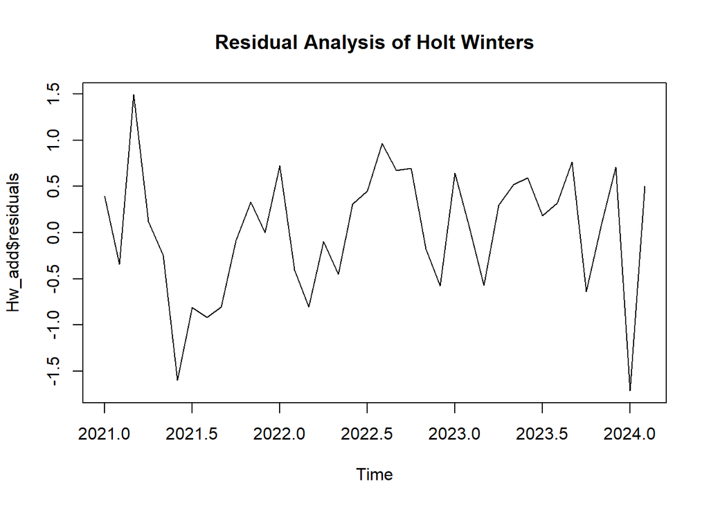

```r
plot(Hw_add$residuals, main = "Residual Analysis of Holt Winters")
```

- Residuals fluctuate around zero, indicating no significant bias in the model.
- No clear pattern suggests residuals are reasonably random.
- Residuals range between -1.5 and +1.5, indicating moderate forecasting errors.
- Occasional larger deviations suggest the model struggles with certain extreme values.
- The residual analysis supports a good fit but highlights potential improvement for outliers.

###### Histogram plot of residuals

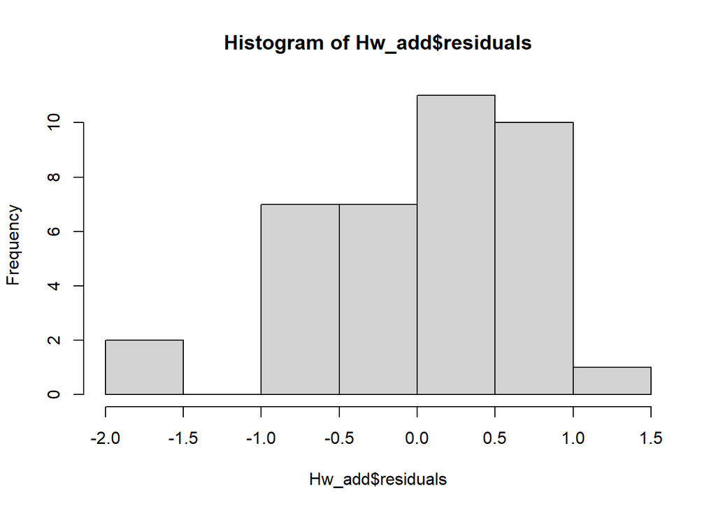

```r
hist(Hw_add$residuals)
```

- Residuals are centered around zero, indicating minimal bias in the model.
- Residuals follow a roughly normal distribution with most values between -1 and 1.
- Few residuals lie beyond -1.5 and +1, suggesting occasional extreme deviations.
- Histogram confirms a good overall fit with random residual distribution.

###### Fitted values vs. residuals

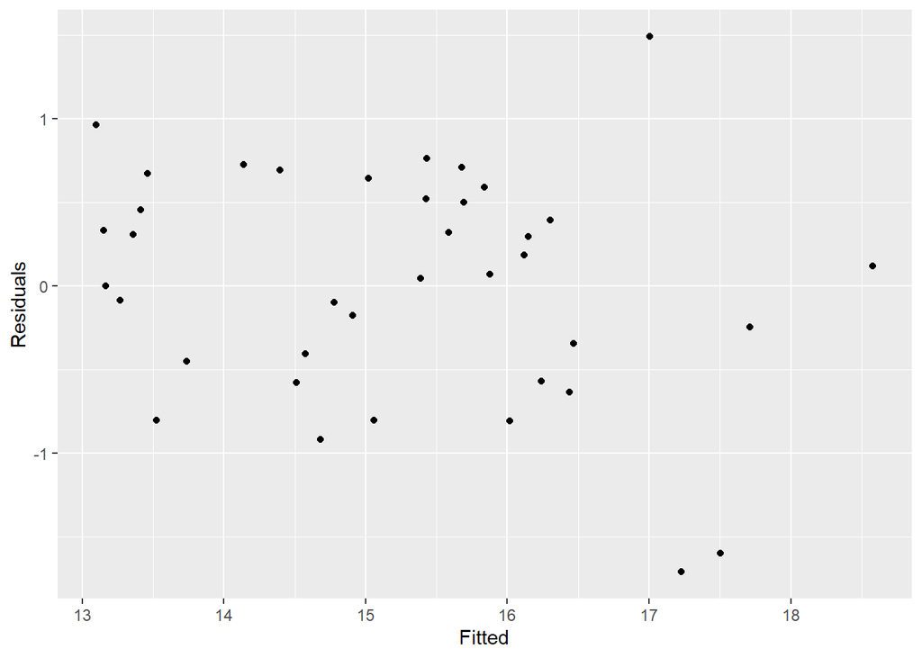

```r
cbind(Fitted = fitted(Hw_add),
      Residuals=residuals(Hw_add)) %>%
  as.data.frame() %>%
  ggplot(aes(x=Fitted, y=Residuals)) + geom_point()
```

- Residuals are scattered randomly around zero, indicating no significant bias.
- The lack of a discernible trend suggests the model adequately captures the data structure.
- Residuals show moderate dispersion across fitted values, with some outliers.
- The plot confirms a reasonable model fit but highlights slight variability at extreme values.

###### Actual values vs. residuals

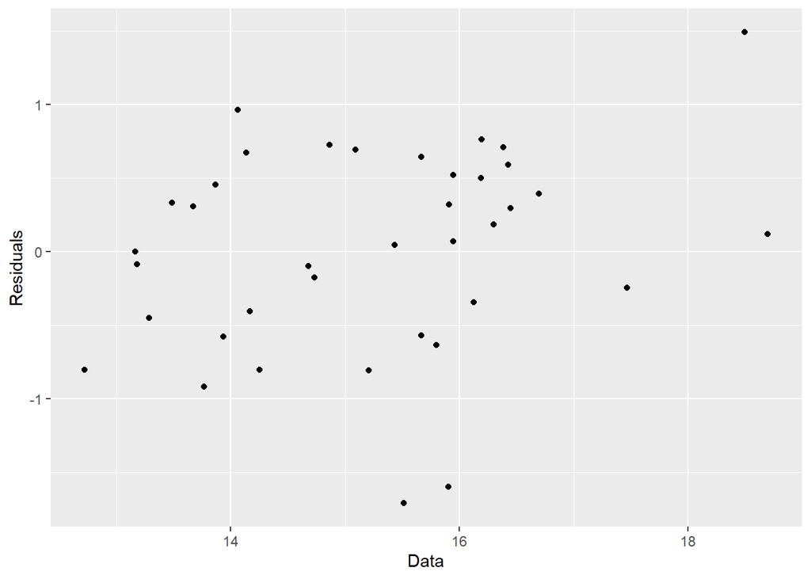

```r
cbind(Data= sales_ts_window,
      Residuals=residuals(Hw_add)) %>%
  as.data.frame() %>%
  ggplot(aes(x=Data, y=Residuals)) + geom_point()
```

###### ACF plot of the residuals

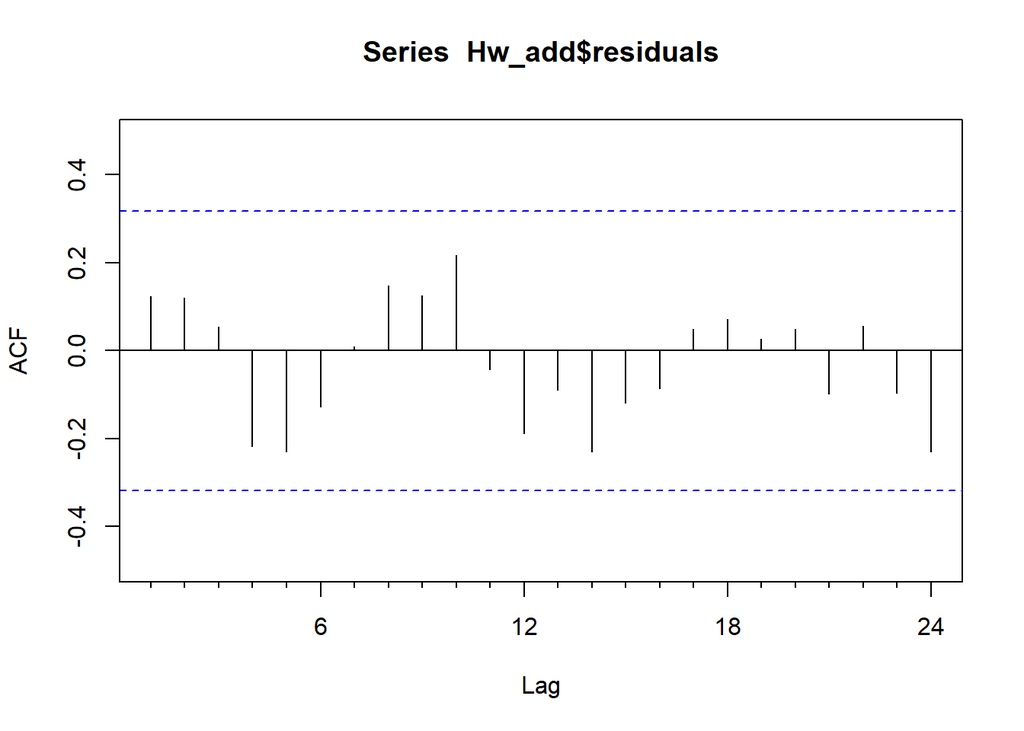

```r
Acf(Hw_add$residuals)
```

- Most residuals fall within the confidence bounds, indicating minimal autocorrelation.
- Residuals exhibit a generally random pattern, confirming a good model fit.
- Small autocorrelation at certain lags suggests mild, insignificant patterns in residuals.
- The plot supports the adequacy of the Holt-Winters additive model for this time series.